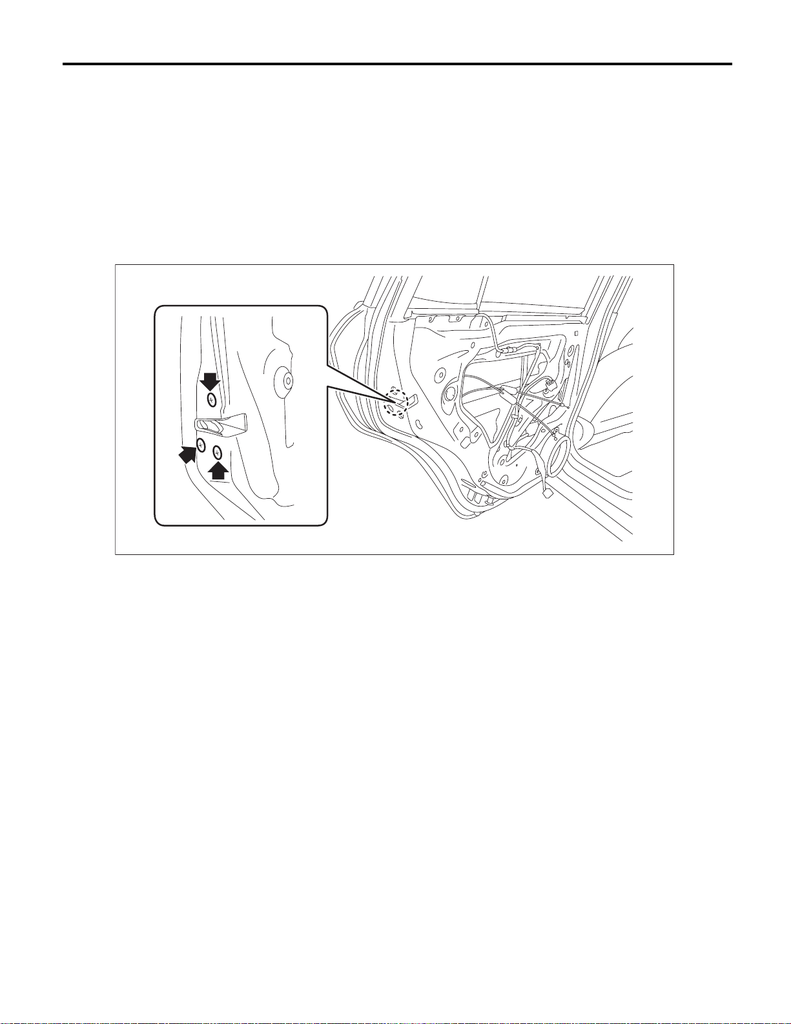

SL-45

Rear Door Latch and Door Lock Actuator Assembly

SECURITY AND LOCKS

13.Rear Door Latch and Door Lock Actuator Assembly

A: REMOVAL

1) Raise the glass assembly - rear door to the top position.

2) Disconnect the ground cable from battery. <Ref. to NT-5, BATTERY, NOTE, Note.>

NOTE:

For models other than STI model, disconnect the ground terminal from battery sensor.

3) Remove the trim panel - rear door. <Ref. to EI-57, REAR DOOR, REMOVAL, Door Trim.>

4) Remove the sealing cover - rear door. <Ref. to EB-41, REMOVAL, Rear Sealing Cover.>

5) Remove the glass assembly - rear door. <Ref. to GW-34, REMOVAL, Rear Door Glass.>

6) Remove the screws to remove the latch & actuator assembly - rear.

B: INSTALLATION

NOTE:

Make sure the child safety lock works correctly after installation.

1) Before installation, check the following items.

• Cable is free from deformation.

• Grease is applied sufficiently to lever joints.

If grease is insufficient, add it as necessary before assembling.

2) Install the latch and actuator assembly - rear.

Tightening torque:

3) Install the glass assembly - rear door. <Ref. to GW-36, INSTALLATION, Rear Door Glass.>

4) Install the sealing cover - rear door.

5) Install the trim panel - rear door.

6) Connect the battery ground terminal. <Ref. to NT-5, BATTERY, NOTE, Note.>

NOTE:

For models other than STI model, connect the ground terminal to battery sensor.

SL-02862

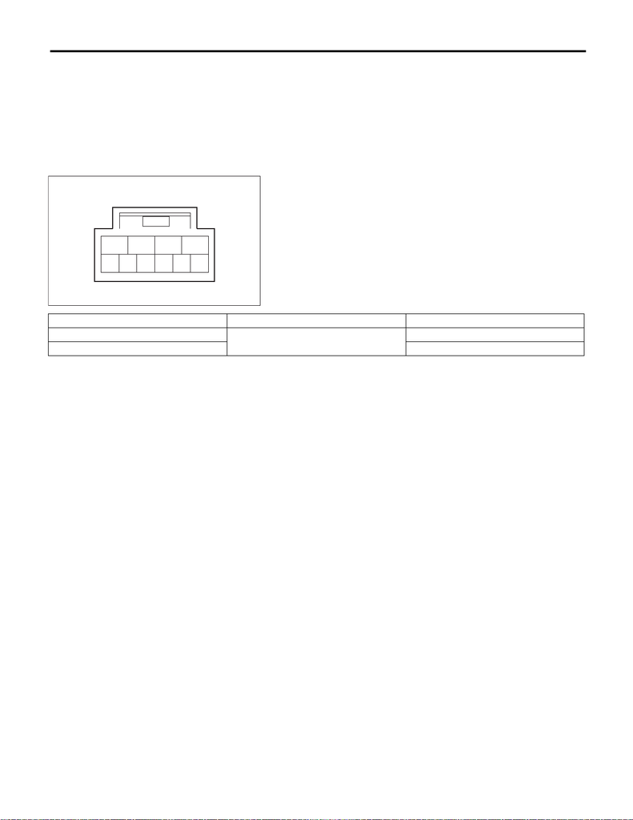

SL-46

Rear Door Latch and Door Lock Actuator Assembly

SECURITY AND LOCKS

C: INSPECTION

1. LATCH

Check if the latch operates normally.

2. ACTUATOR

1) Check door lock operation

Check the door lock operation when battery voltage is applied between the connectors.

2) If it does not operate properly as a result of inspection, replace the latch & actuator assembly - rear.

SL-02880

1

10

Terminal No. Inspection conditions Standard

4 (+) — 1 (–)

Apply battery voltage.

LOCK

1 (+) — 4 (–) UNLOCK